# Practical A

Gerko Vink

We use the following packages in this Practical:

```r
library(dplyr)     # for data manipulation
library(magrittr)  # for pipes
library(ggplot2)   # for visualization
library(mice)      # for the boys data
```

# Exercises

## Pipes

1. **Use a pipe to do the following:**
- draw 1000 values from a normal distribution with `mean = 5` and `sd = 1` - $N(5, 1)$,
- create a matrix where the first 500 values are the first column and the second 500 values are the second column **
- make a scatterplot of these two columns
2. **Use a pipe to calculate the correlation matrix on the `anscombe` data set**
3. **Now use a pipe to calculate the correlation for the pair (`x4`, `y4`) on the `anscombe` data set**

The `boys` dataset is part of package `mice`. It is a subset of 748 Dutch boystaken from the Fourth Dutch Growth Study. It’s columns record a variety of growth measures. Inspect the help for `boys` dataset and make yourself familiar with its contents.**

To learn more about the contents of the data, use one of the two following help commands:

```r
help(boys)
?boys
```

4. **It seems that the `boys` data are sorted based on `age`. Verify this.**
5. **Use a pipe to calculate the correlation between `hgt` and `wgt` in the `boys` data set from package `mice`.**
6. **In the `boys` data set, `hgt` is recorded in centimeters. Use a pipe to transform `hgt` in the `boys` dataset to height in meters and verify the transformation**
7. **Use a pipe to plot the pair (`hgt`, `wgt`) two times: once for `hgt` in meters and once for `hgt` in centimeters. Make the points in the ‘centimeter’ plot `red` and in the ‘meter’ plot `blue`.**

## Visualization

8. **Function `plot()` is the core plotting function in `R`. Find out more about `plot()`: Try both the help in the help-pane and `?plot` in the console. Look at the examples by running `example(plot)`.**
9. **Create a scatterplot between `age` and `bmi` in the `mice::boys` data set**
10. **Now recreate the plot with the following specifications:**
- If `bmi < 18.5` use `color = "light blue"`
- If `bmi > 18.5 & bmi < 25` use `color = "light green"`
- If `bmi > 25 & bmi < 30` use `color = "orange"`
- If `bmi > 30` use `color = "red"`

Hint: it may help to expand the data set with a new variable.

11. **Create a histogram for `age` in the `boys` data set**
12. **Create a bar chart for `reg` in the boys data set**
13. **Create a box plot for `hgt` with different boxes for `reg` in the `boys` data set**
14. **Create a density plot for `age` with different curves for boys from the `city` and boys from rural areas (`!city`).**
15. **Create a diverging bar chart for `hgt` in the `boys` data set, that displays for every `age` year that year’s mean height in deviations from the overall average `hgt`**

In other words; recreate the following plot:

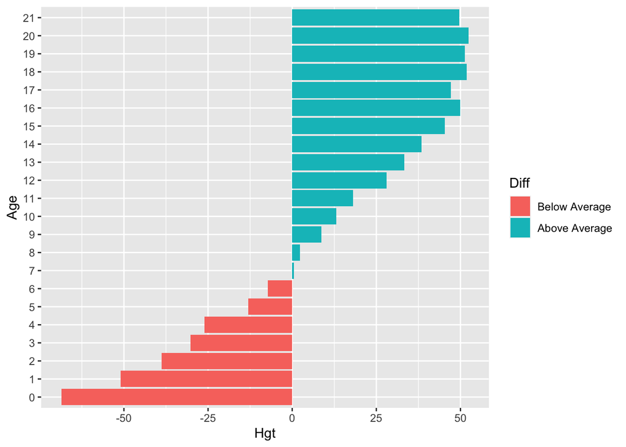

End of Practical

# Useful References

- [The `ggplot2` reference page](https://ggplot2.tidyverse.org/reference/index.html)
- [`magrittr`](https://magrittr.tidyverse.org)
- [`R` for Data Science](http://r4ds.had.co.nz) - [Chapter 18 on pipes](http://r4ds.had.co.nz/pipes.html)
- Anscombe, Francis J. (1973) [Graphs in statistical analysis](http://www.sjsu.edu/faculty/gerstman/StatPrimer/anscombe1973.pdf). American Statistician, 27, 17–21.